# Chapter 9 Amplicon t0_p30 filtering vs genome resolved metagenomics

```r
load("resources/metagenomics/data_filtered.Rdata")
load("resources/amplicon/second_filtering_t0_p30.Rdata")
```

## 9.1 Taxonomy

*Number of MAGs in metagenomic data*

```r
cat(nrow(genome_metadata))
```

```
135
```

*Number of ASVs in amplicon data*

```r
cat(nrow(genome_metadata_amplicon))
```

```
124
```

### 9.1.1 Phylum

*Number of phyla in metagenomic data*

```r
cat(genome_metadata %>%
      distinct(domain, phylum) %>%
      count() %>%
      pull())
```

```
15
```

*Number of phyla in amplicon data*

```r
cat(genome_metadata_amplicon %>%
      distinct(domain, phylum) %>%
      count() %>%
      pull())
```

```
10
```

*Shared phyla*

```r
meta_phylum <- genome_metadata %>%
  distinct(domain,phylum)

genome_metadata_amplicon %>%
  distinct(domain,phylum) %>%
  filter(phylum %in% meta_phylum$phylum)
```

```
    domain           phylum
1 Bacteria   Pseudomonadota
2 Bacteria   Fusobacteriota
3 Bacteria        Bacillota
4 Bacteria     Synergistota
5 Bacteria Desulfobacterota
6 Bacteria Campylobacterota
7 Bacteria     Bacteroidota
8 Bacteria  Planctomycetota
```

*Only in metagenomic data*

```r
ampli_phylum <- genome_metadata_amplicon %>%
  distinct(domain,phylum)
genome_metadata %>%
  distinct(domain,phylum) %>%
  filter(!phylum %in% genome_metadata_amplicon$phylum)
```

```
    domain           phylum
1 Bacteria    Spirochaetota
2 Bacteria Deferribacterota
3 Bacteria   Actinomycetota
4 Bacteria      Bacillota_A
5 Bacteria      Bacillota_C
6 Bacteria  Cyanobacteriota
7 Bacteria  Elusimicrobiota
```

*Only in amplicon data*

```r
genome_metadata_amplicon %>%
  distinct(domain,phylum) %>%
  filter(!phylum %in% meta_phylum$phylum)
```

```
    domain               phylum
1 Bacteria Rs-K70 termite group
2 Bacteria      Patescibacteria
```

### 9.1.2 Family

*Number of families in metagenomic data*

```r
cat(genome_metadata %>%
      distinct(domain, phylum, family) %>%
      count() %>%
      pull())
```

```
56
```

*Number of families in amplicon data*

```r
cat(genome_metadata_amplicon %>%
      distinct(domain, phylum, family) %>%
      count() %>%
      pull())
```

```
39
```

*Shared families*

```r
meta_family <- genome_metadata %>%
  distinct(domain, phylum, family)

genome_metadata_amplicon %>%
  distinct(domain, phylum, family) %>%
  filter(family %in% meta_family$family)
```

```
     domain           phylum              family
1  Bacteria   Pseudomonadota Diplorickettsiaceae
2  Bacteria   Pseudomonadota        Vibrionaceae
3  Bacteria   Pseudomonadota  Enterobacteriaceae
4  Bacteria   Fusobacteriota    Leptotrichiaceae
5  Bacteria        Bacillota     Enterococcaceae
6  Bacteria   Pseudomonadota     Pasteurellaceae
7  Bacteria   Pseudomonadota      Aeromonadaceae
8  Bacteria        Bacillota    Streptococcaceae
9  Bacteria     Synergistota      Synergistaceae
10 Bacteria   Pseudomonadota    Burkholderiaceae
11 Bacteria Desulfobacterota Desulfovibrionaceae
12 Bacteria   Fusobacteriota    Fusobacteriaceae
13 Bacteria   Pseudomonadota      Rhodocyclaceae
14 Bacteria        Bacillota Erysipelotrichaceae
15 Bacteria Campylobacterota   Helicobacteraceae
16 Bacteria     Bacteroidota      Bacteroidaceae
17 Bacteria   Pseudomonadota     Anaplasmataceae
18 Bacteria        Bacillota     Ruminococcaceae
19 Bacteria        Bacillota     Lachnospiraceae
20 Bacteria     Bacteroidota   Dysgonomonadaceae
21 Bacteria        Bacillota Christensenellaceae
22 Bacteria     Bacteroidota      Tannerellaceae
23 Bacteria   Pseudomonadota    Acetobacteraceae
```

*Only in metagenomic data*

```r
ampli_family <- genome_metadata_amplicon %>%
  distinct(domain, phylum, family)
genome_metadata %>%
  distinct(domain, phylum, family) %>%
  filter(!family %in% ampli_family$family)
```

```
     domain           phylum               family
1  Bacteria    Spirochaetota               WRBN01
2  Bacteria  Planctomycetota             SZUA-567
3  Bacteria     Bacteroidota               UBA932
4  Bacteria     Bacteroidota        Rikenellaceae
5  Bacteria     Bacteroidota        Weeksellaceae
6  Bacteria Campylobacterota   Campylobacteraceae
7  Bacteria Deferribacterota     Mucispirillaceae
8  Bacteria   Pseudomonadota              CAG-239
9  Bacteria   Pseudomonadota
10 Bacteria   Pseudomonadota         Rhizobiaceae
11 Bacteria   Pseudomonadota     Beijerinckiaceae
12 Bacteria   Pseudomonadota       Rickettsiaceae
13 Bacteria   Pseudomonadota        Chromatiaceae
14 Bacteria   Pseudomonadota       Halomonadaceae
```

[output cut: 19 more lines]

*Only in amplicon data*

```r
genome_metadata_amplicon %>%
  distinct(domain, phylum, family) %>%
  filter(!family %in% meta_family$family)
```

```
     domain               phylum                             family
1  Bacteria       Pseudomonadota                       Yersiniaceae
2  Bacteria       Pseudomonadota                     Morganellaceae
3  Bacteria            Bacillota                        Bacillaceae
4  Bacteria Rs-K70 termite group                               <NA>
5  Bacteria            Bacillota                      Aerococcaceae
6  Bacteria       Pseudomonadota                               <NA>
7  Bacteria            Bacillota                 Acidaminococcaceae
8  Bacteria            Bacillota              Peptostreptococcaceae
9  Bacteria            Bacillota                   Lactobacillaceae
10 Bacteria      Planctomycetota                               <NA>
11 Bacteria            Bacillota [Clostridium] methylpentosum group
12 Bacteria       Pseudomonadota                   Pseudomonadaceae
13 Bacteria      Patescibacteria                               <NA>
14 Bacteria            Bacillota                               <NA>
15 Bacteria       Pseudomonadota                  Nitrosomonadaceae
16 Bacteria            Bacillota          Erysipelatoclostridiaceae
```

## 9.2 Alpha Diversity

### 9.2.1 Merge both data

```r
richness <- genome_counts_filt_amplicon %>%
  column_to_rownames(var = "genome") %>%
  dplyr::select(where(~ !all(. == 0))) %>%
  hilldiv(., q = 0) %>%
  t() %>%
  as.data.frame() %>%
  dplyr::rename(richness = 1) %>%
  rownames_to_column(var = "sample")

neutral <- genome_counts_filt_amplicon %>%
  column_to_rownames(var = "genome") %>%
  dplyr::select(where(~ !all(. == 0))) %>%
  hilldiv(., q = 1) %>%
  t() %>%
  as.data.frame() %>%
  dplyr::rename(neutral = 1) %>%
  rownames_to_column(var = "sample")

amplicon_alpha_div <- richness %>%
  full_join(neutral, by = join_by(sample == sample)) %>%
  mutate(method = "amplicon")
```

```r
metagenome_alpha_div <- readRDS("resources/metagenomics/metagenome_alpha_div.rds") %>%
  select(sample, richness, neutral, method)

join_alpha <- rbind(metagenome_alpha_div, amplicon_alpha_div) %>%
  left_join(sample_metadata, by = join_by(sample == sample))
```

### 9.2.2 Comparison

#### 9.2.2.1 Differences between methods and species

*Richness*

```r
Model_richness <- lm(formula = richness ~ Species*method, data = join_alpha)
anova(Model_richness)
```

```
Analysis of Variance Table

Response: richness
               Df  Sum Sq Mean Sq F value    Pr(>F)
Species         2  7613.9  3806.9 30.3500 6.105e-11 ***
method          1   617.7   617.7  4.9241  0.028839 *
Species:method  2  1612.1   806.1  6.4261  0.002403 **
Residuals      96 12041.7   125.4
---
Signif. codes:  0 '***' 0.001 '**' 0.01 '*' 0.05 '.' 0.1 ' ' 1
```

*Neutral*

```r
Model_neutral <- lm(formula = neutral ~ Species*method, data = join_alpha)
anova(Model_neutral)
```

```
Analysis of Variance Table

Response: neutral
               Df  Sum Sq Mean Sq F value   Pr(>F)
Species         2  258.74 129.368  8.0148 0.000604 ***
method          1    1.55   1.546  0.0958 0.757648
Species:method  2  100.77  50.384  3.1214 0.048600 *
Residuals      96 1549.56  16.141
---
Signif. codes:  0 '***' 0.001 '**' 0.01 '*' 0.05 '.' 0.1 ' ' 1
```

##### 9.2.2.1.1 Metagenomic data

```r
alpha_div_meta <- metagenome_alpha_div %>%
  left_join(sample_metadata, by = join_by(sample == sample))
```

*Richness*

```r
Model_richness <- lm(formula = richness ~ Species, data = alpha_div_meta)
anova(Model_richness)
```

```
Analysis of Variance Table

Response: richness
          Df Sum Sq Mean Sq F value    Pr(>F)
Species    2   1704  852.00  8.4391 0.0007235 ***
Residuals 48   4846  100.96
---
Signif. codes:  0 '***' 0.001 '**' 0.01 '*' 0.05 '.' 0.1 ' ' 1
```

```r
emmeans(Model_richness, pairwise ~ Species)
```

```
$emmeans
 Species emmean   SE df lower.CL upper.CL
 Eb       19.70 3.18 48    13.31    26.09
 Ha        3.58 2.31 48    -1.06     8.21
 Pk        8.82 2.14 48     4.51    13.13

Confidence level used: 0.95

$contrasts
 contrast estimate   SE df t.ratio p.value
 Eb - Ha     16.12 3.93 48   4.107  0.0004
 Eb - Pk     10.88 3.83 48   2.840  0.0178
 Ha - Pk     -5.24 3.15 48  -1.665  0.2291

P value adjustment: tukey method for comparing a family of 3 estimates
```

*Neutral*

```r
Model_neutral <- lm(formula = neutral ~ Species, data = alpha_div_meta)
anova(Model_neutral)
```

```
Analysis of Variance Table

Response: neutral
          Df  Sum Sq Mean Sq F value  Pr(>F)
Species    2  190.82  95.411  4.1954 0.02093 *
Residuals 48 1091.60  22.742
---
Signif. codes:  0 '***' 0.001 '**' 0.01 '*' 0.05 '.' 0.1 ' ' 1
```

```r
emmeans(Model_neutral, pairwise ~ Species)
```

```
$emmeans
 Species emmean   SE df lower.CL upper.CL
 Eb        7.33 1.51 48   4.2937    10.36
 Ha        2.15 1.09 48  -0.0467     4.35
 Pk        5.05 1.02 48   3.0060     7.09

Confidence level used: 0.95

$contrasts
 contrast estimate   SE df t.ratio p.value
 Eb - Ha      5.17 1.86 48   2.776  0.0210
 Eb - Pk      2.28 1.82 48   1.251  0.4295
 Ha - Pk     -2.90 1.49 48  -1.940  0.1386

P value adjustment: tukey method for comparing a family of 3 estimates
```

##### 9.2.2.1.2 Amplicon data

```r
alpha_div_ampli <- amplicon_alpha_div %>%
  left_join(sample_metadata, by = join_by(sample == sample))
```

*Richness*

```r
Model_richness <- lm(formula = richness ~ Species, data = alpha_div_ampli)
anova(Model_richness)
```

```
Analysis of Variance Table

Response: richness
          Df Sum Sq Mean Sq F value   Pr(>F)
Species    2 7522.0  3761.0  25.088 3.48e-08 ***
Residuals 48 7195.7   149.9
---
Signif. codes:  0 '***' 0.001 '**' 0.01 '*' 0.05 '.' 0.1 ' ' 1
```

```r
emmeans(Model_richness, pairwise ~ Species)
```

```
$emmeans
 Species emmean   SE df lower.CL upper.CL
 Eb        38.2 3.87 48   30.415     46.0
 Ha        10.3 2.81 48    4.668     16.0
 Pk         6.0 2.61 48    0.751     11.2

Confidence level used: 0.95

$contrasts
 contrast estimate   SE df t.ratio p.value
 Eb - Ha     27.88 4.78 48   5.829  <.0001
 Eb - Pk     32.20 4.67 48   6.896  <.0001
 Ha - Pk      4.32 3.83 48   1.125  0.5033

P value adjustment: tukey method for comparing a family of 3 estimates
```

*Neutral*

```r
Model_neutral <- lm(formula = neutral ~ Species, data = alpha_div_ampli)
anova(Model_neutral)
```

```
Analysis of Variance Table

Response: neutral
          Df Sum Sq Mean Sq F value    Pr(>F)
Species    2 168.68  84.341  8.8401 0.0005387 ***
Residuals 48 457.96   9.541
---
Signif. codes:  0 '***' 0.001 '**' 0.01 '*' 0.05 '.' 0.1 ' ' 1
```

```r
emmeans(Model_neutral, pairwise ~ Species)
```

```
$emmeans
 Species emmean    SE df lower.CL upper.CL
 Eb        7.59 0.977 48     5.63     9.55
 Ha        4.15 0.709 48     2.72     5.57
 Pk        2.64 0.659 48     1.31     3.96

Confidence level used: 0.95

$contrasts
 contrast estimate    SE df t.ratio p.value
 Eb - Ha      3.44 1.210 48   2.851  0.0173
 Eb - Pk      4.95 1.180 48   4.205  0.0003
 Ha - Pk      1.51 0.967 48   1.564  0.2709

P value adjustment: tukey method for comparing a family of 3 estimates
```

## 9.3 Beta diversity

### 9.3.1 Prepare the data

```r
load("resources/amplicon/second_filtering_t0_p30.Rdata")
```

*Calculate beta diversity in amplicon data*

```r
beta_q0n_ampli <- genome_counts_filt_amplicon %>%
  column_to_rownames(., "genome") %>%
  filter(rowSums(. != 0, na.rm = TRUE) > 0) %>%
  select_if( ~ !all(. == 0)) %>%
  hillpair(., q = 0)

beta_q1n_ampli <- genome_counts_filt_amplicon %>%
  column_to_rownames(., "genome") %>%
  filter(rowSums(. != 0, na.rm = TRUE) > 0) %>%
  select_if( ~ !all(. == 0)) %>%
  hillpair(., q = 1)
```

*Check for outliers in amplicon data*

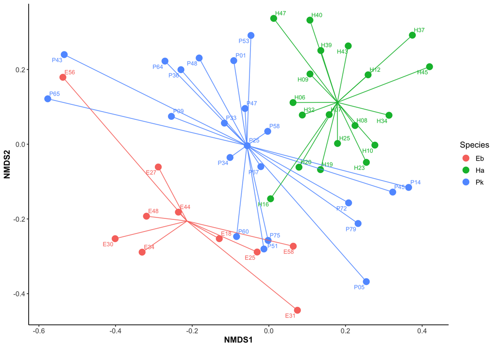

```r
beta_q1n_ampli$S %>%
  vegan::metaMDS(.,
                 trymax = 500,
                 k = 2,
                 trace = 0) %>%
  vegan::scores() %>%
  as_tibble(., rownames = "sample") %>%
  dplyr::left_join(sample_metadata_amplicon, by = join_by(sample == sample)) %>%
  group_by(Species) %>%
  mutate(x_cen = mean(NMDS1, na.rm = TRUE)) %>%
  mutate(y_cen = mean(NMDS2, na.rm = TRUE)) %>%
  ungroup() %>%
  ggplot(aes(x = NMDS1, y = NMDS2, color = Species)) +
  geom_point(size = 4) +
  geom_segment(
    aes(
      x = x_cen,
      y = y_cen,
      xend = NMDS1,
      yend = NMDS2
    ),
    alpha = 0.9,
    show.legend = FALSE
  ) +
  theme(
    axis.title = element_text(size = 12, face = "bold"),
    axis.text = element_text(size = 10),
    panel.background = element_blank(),
    axis.line = element_line(
      size = 0.5,
      linetype = "solid",
      colour = "black"
    ),
    legend.text = element_text(size = 10),
    legend.title = element_text(size = 12),
    legend.position = "right",
    legend.box = "vertical"
  ) +
  labs(color = "Species")+geom_text_repel(aes(label = sample), size=3)
```

E31 has been considered an outlier in the previous threshold but here it doesn’t look like an outlier

```r
sample_metadata_amplicon <- sample_metadata_amplicon %>%
  mutate(method="amplicon")

rich_beta_amplicon <- beta_q0n_ampli$S %>%
  vegan::metaMDS(.,
                 trymax = 500,
                 k = 2,
                 trace = 0) %>%
  vegan::scores() %>%
  as_tibble(., rownames = "sample") %>%
  dplyr::left_join(sample_metadata_amplicon, by = join_by(sample == sample)) %>%
  mutate(individual=sample)%>%
  mutate(sample = paste0(sample, "_ampli")) %>%
  select(sample,NMDS1,NMDS2,Species,method, individual)

neutral_beta_amplicon <- beta_q1n_ampli$S %>%
  vegan::metaMDS(.,
                 trymax = 500,
                 k = 2,
                 trace = 0) %>%
  vegan::scores() %>%
  as_tibble(., rownames = "sample") %>%
  dplyr::left_join(sample_metadata_amplicon, by = join_by(sample == sample)) %>%
  mutate(individual=sample)%>%
  mutate(sample = paste0(sample, "_ampli")) %>%
  select(sample,NMDS1,NMDS2,Species,method,individual)
```

*Calculate beta diversity in metagenomic data*

```r
load("resources/metagenomics/data_filtered.Rdata")
load("resources/metagenomics/beta_filtered.Rdata")
sample_metadata <- sample_metadata %>%
  filter(!sample %in% c("H06", "H20"))
```

```r
sample_metadata <- sample_metadata %>%
  mutate(method="shotgun")

rich_beta_meta <- beta_q0n$S %>%
  vegan::metaMDS(.,
                 trymax = 500,
                 k = 2,
                 trace = 0) %>%
  vegan::scores() %>%
  as_tibble(., rownames = "sample") %>%
  dplyr::left_join(sample_metadata, by = join_by(sample == sample))%>%
  mutate(individual=sample)%>%
  select(sample,NMDS1,NMDS2,Species,method, individual)

neutral_beta_meta <- beta_q1n$S %>%
  vegan::metaMDS(.,
                 trymax = 500,
                 k = 2,
                 trace = 0) %>%
  vegan::scores() %>%
  as_tibble(., rownames = "sample") %>%
  dplyr::left_join(sample_metadata, by = join_by(sample == sample)) %>%
  mutate(individual=sample)%>%
  select(sample,NMDS1,NMDS2,Species,method, individual)
```

### 9.3.2 Comparison

#### 9.3.2.1 Richness

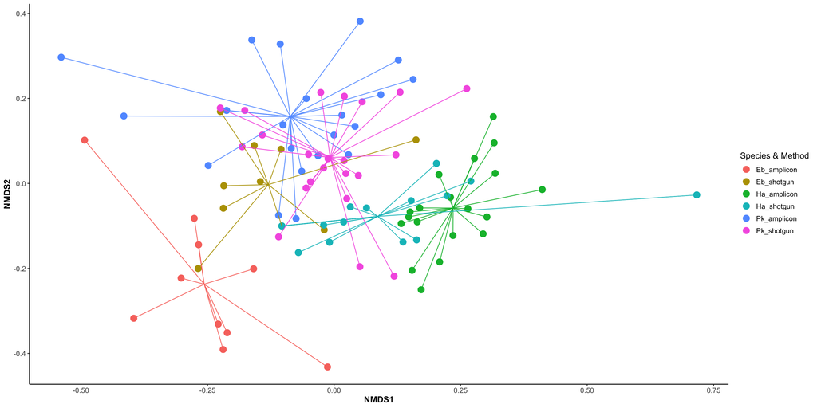

```r
beta_richness_together <- rbind(rich_beta_amplicon, rich_beta_meta) %>%
  mutate(id = paste(Species, method, sep = "_"))
beta_colors <- c("#e5bd5b","#d57d2c","#6b7398","#ea68c3","#76b183","#3c634e")
beta_richness_together %>%
  group_by(id) %>%
  mutate(x_cen = mean(NMDS1, na.rm = TRUE)) %>%
  mutate(y_cen = mean(NMDS2, na.rm = TRUE)) %>%
  ungroup() %>%
  ggplot(aes(x = NMDS1, y = NMDS2, color = id)) +
  geom_point(size = 4) +
  geom_segment(
    aes(
      x = x_cen,
      y = y_cen,
      xend = NMDS1,
      yend = NMDS2
    ),
    alpha = 0.9,
    show.legend = FALSE
  ) +
  theme(
    axis.title = element_text(size = 12, face = "bold"),
    axis.text = element_text(size = 10),
    panel.background = element_blank(),
    axis.line = element_line(
      size = 0.5,
      linetype = "solid",
      colour = "black"
    ),
    legend.text = element_text(size = 10),
    legend.title = element_text(size = 12),
    legend.position = "right",
    legend.box = "vertical"
  ) +
  labs(color = "Species & Method")
```

*Differences between species and methods*

```r
metadata_both <- beta_richness_together %>%
  select(sample, Species, method, individual, id)
dist_matrix <- dist(beta_richness_together %>% select(NMDS1, NMDS2), method = "euclidean")
dist_matrix <- as.matrix(dist_matrix)
rownames(dist_matrix) <- beta_richness_together$sample
colnames(dist_matrix) <- beta_richness_together$sample

adonis2(dist_matrix ~ method*Species,
        data = metadata_both %>% arrange(match(sample,labels(dist_matrix))),
        permutations = 999, by="terms") %>%
        broom::tidy() %>%
        tt()
```

| term | df | SumOfSqs | R2 | statistic | p.value |
| --- | --- | --- | --- | --- | --- |
| method | 1 | 1.319317e-17 | 1.961316e-18 | 3.874229e-16 | 1.000 |
| Species | 2 | 2.798875e+00 | 4.160850e-01 | 4.109507e+01 | 0.001 |
| method:Species | 2 | 7.267715e-01 | 1.080430e-01 | 1.067098e+01 | 0.001 |
| Residual | 94 | 3.201043e+00 | 4.758720e-01 | NA | NA |
| Total | 99 | 6.726690e+00 | 1.000000e+00 | NA | NA |

#### 9.3.2.2 Neutral

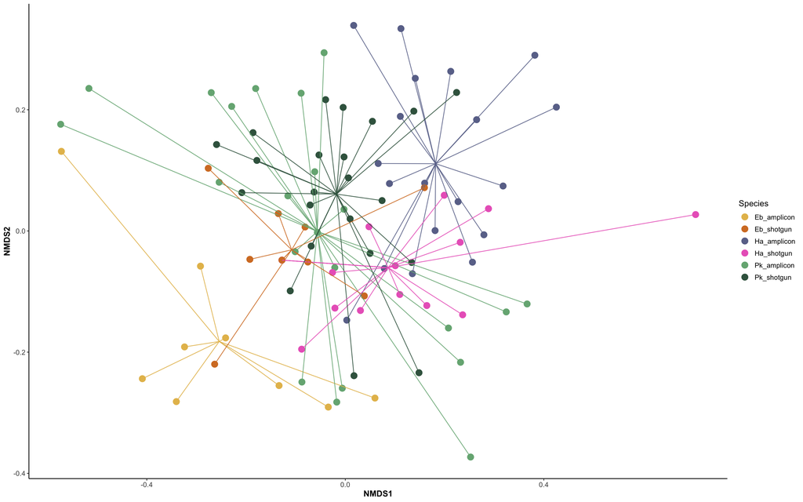

```r
beta_neutral_together <- rbind(neutral_beta_amplicon, neutral_beta_meta) %>%
  mutate(id = paste(Species, method, sep = "_"))
beta_colors <- c("#e5bd5b","#d57d2c","#6b7398","#ea68c3","#76b183","#3c634e")

beta_neutral_together %>%
  filter(sample != "E31_ampli") %>%
  group_by(id) %>%
  mutate(x_cen = mean(NMDS1, na.rm = TRUE)) %>%
  mutate(y_cen = mean(NMDS2, na.rm = TRUE)) %>%
  ungroup() %>%
  ggplot(aes(x = NMDS1, y = NMDS2, color = id)) +
  geom_point(size = 4) +
  scale_color_manual(values = beta_colors) +
  geom_segment(
    aes(
      x = x_cen,
      y = y_cen,
      xend = NMDS1,
      yend = NMDS2
    ),
    alpha = 0.9,
    show.legend = FALSE
  ) +
  theme(
    axis.title = element_text(size = 12, face = "bold"),
    axis.text = element_text(size = 10),
    panel.background = element_blank(),
    axis.line = element_line(
      size = 0.5,
      linetype = "solid",
      colour = "black"
    ),
    legend.text = element_text(size = 10),
    legend.title = element_text(size = 12),
    legend.position = "right",
    legend.box = "vertical"
  ) +
  labs(color = "Species")
```

*Differences between species and methods*

```r
metadata_both <- beta_neutral_together %>%
  select(sample, Species, method, individual, id)
dist_matrix <- dist(beta_neutral_together %>% select(NMDS1, NMDS2), method = "euclidean")
dist_matrix <- as.matrix(dist_matrix)
rownames(dist_matrix) <- beta_neutral_together$sample
colnames(dist_matrix) <- beta_neutral_together$sample

adonis2(dist_matrix ~ method*Species,
        data = metadata_both %>% arrange(match(sample,labels(dist_matrix))),
        permutations = 999, by="terms") %>%
        broom::tidy() %>%
        tt()
```

| term | df | SumOfSqs | R2 | statistic | p.value |
| --- | --- | --- | --- | --- | --- |
| method | 1 | 6.876667e-17 | 9.428701e-18 | 1.285812e-15 | 1.000 |
| Species | 2 | 1.639884e+00 | 2.248469e-01 | 1.533142e+01 | 0.001 |
| method:Species | 2 | 6.262253e-01 | 8.586269e-02 | 5.854639e+00 | 0.001 |
| Residual | 94 | 5.027226e+00 | 6.892904e-01 | NA | NA |
| Total | 99 | 7.293334e+00 | 1.000000e+00 | NA | NA |

## 9.4 Differential abundace analysis at phylum level

```r
phylo_samples <- sample_metadata %>%
  mutate(individual=sample)%>%
  column_to_rownames("sample") %>%
  mutate(method="shotgun") %>%
  select(1,8,9) %>%
  sample_data()
phylo_genome <- genome_counts_filt %>%
  select(one_of(c("genome",rownames(phylo_samples)))) %>%
  filter(rowSums(across(where(is.numeric), ~ . != 0)) > 0) %>%
  select(genome, where(~ is.numeric(.) && sum(.) > 0)) %>%
  column_to_rownames("genome") %>%
  otu_table(., taxa_are_rows = TRUE)
phylo_taxonomy <- genome_metadata %>%
  filter(genome %in% rownames(phylo_genome)) %>%
  column_to_rownames("genome") %>%
  dplyr::select(domain,phylum,class,order,family,genus,species) %>%
  as.matrix() %>%
  tax_table()

physeq_genome_filtered <- phyloseq(phylo_genome, phylo_taxonomy, phylo_samples)
physeq_genome_filtered_phylum <- tax_glom(physeq_genome_filtered, "phylum")
```

```r
phylo_samples <- sample_metadata_amplicon %>%
  mutate(individual=sample)%>%
  mutate(sample = paste0(sample, "_ampli"))%>%
  column_to_rownames("sample")  %>%
  mutate(method="amplicon")%>%
  select(12,15,16) %>%
  sample_data()
phylo_genome <- genome_counts_filt_amplicon%>%
  rename_with(~ paste0(., "_ampli")) %>%
  select(one_of(c("genome_ampli",rownames(phylo_samples)))) %>%
  filter(rowSums(across(where(is.numeric), ~ . != 0)) > 0) %>%
  select(genome_ampli, where(~ is.numeric(.) && sum(.) > 0)) %>%
  column_to_rownames("genome_ampli") %>%
  otu_table(., taxa_are_rows = TRUE)
phylo_taxonomy <- genome_metadata_amplicon %>%
  filter(genome %in% rownames(phylo_genome)) %>%
  mutate(genome2 = genome) %>%
  column_to_rownames("genome2") %>%
  dplyr::select(domain, phylum, class, order, family, genus, species, genome) %>%
  as.matrix() %>%
  tax_table()

physeq_genome_filtered_ampl <- phyloseq(phylo_genome, phylo_taxonomy, phylo_samples)
physeq_genome_filtered_ampl_phylum <- tax_glom(physeq_genome_filtered_ampl, "phylum")

merge_phylo <- merge_phyloseq(physeq_genome_filtered_ampl_phylum,physeq_genome_filtered_phylum)
```

```r
#create the merge phyloseq object at phylum level
otu1 <- as.data.frame(otu_table(physeq_genome_filtered_phylum))
tax1 <- as.data.frame(tax_table(physeq_genome_filtered_phylum)) %>% select(phylum)
otu1$phylum <- tax1$phylum

otu2 <- as.data.frame(otu_table(physeq_genome_filtered_ampl_phylum))
tax2 <- as.data.frame(tax_table(physeq_genome_filtered_ampl_phylum)) %>% select(phylum)
otu2$phylum <- tax2$phylum

merged_otu <- full_join(otu1, otu2, by = "phylum") %>%
  mutate(across(everything(), ~replace_na(., 0)))%>%
  group_by(phylum) %>%
  summarise(across(everything(), sum, na.rm = TRUE))
merged_otu_mat <- as.matrix(merged_otu %>% select(-phylum))
rownames(merged_otu_mat) <- merged_otu$phylum
otu_table_merged <- otu_table(merged_otu_mat, taxa_are_rows = TRUE)

merged_physeq_phylum <- phyloseq(otu_table_merged, sample_data(merge_phylo))
```

### 9.4.1 Eptesicus

```r
physeq_eb <- subset_samples(merged_physeq_phylum, Species == "Eb")
physeq_eb <- prune_taxa(taxa_sums(physeq_eb)>0, physeq_eb)
```

```r
ancom_rand_output_struc_eb = ancombc2(data = physeq_eb,
                  assay_name = "counts",
                  tax_level = NULL,
                  fix_formula = "method",
                  rand_formula = "(1|individual)",
                  p_adj_method = "holm",
                  pseudo_sens = TRUE,
                  prv_cut =0,
                  lib_cut = 0,
                  s0_perc = 0.05,
                  group = "method",
                  struc_zero = TRUE,
                  neg_lb = FALSE,
                  alpha = 0.05,
                  n_cl = 2,
                  verbose = TRUE,
                  global = FALSE,
                  pairwise = FALSE,
                  dunnet = FALSE,
                  trend = FALSE,
                  iter_control = list(tol = 1e-5, max_iter = 20, verbose = FALSE),
                  em_control = list(tol = 1e-5, max_iter = 100),
                  lme_control = lme4::lmerControl(),
                  mdfdr_control = list(fwer_ctrl_method = "holm", B = 100),
                  trend_control = NULL)
```

*Total structural zeros*

```r
structural_zeros <- ancom_rand_output_struc_eb$zero_ind

structural_zeros_df <- as.data.frame(structural_zeros) %>%
  column_to_rownames(., "taxon")

structural_zero_taxa <- rownames(structural_zeros_df)[apply(structural_zeros_df, 1, any)]

structural_zero_groups <- structural_zeros_df[structural_zero_taxa, , drop = FALSE] %>%
  rename("amplicon"=1) %>%
  rename("shotgun"=2)

nrow(structural_zero_groups)
```

```
[1] 6
```

*Structural zeros in amplicon*

```r
structural_zero_groups %>%
  filter(amplicon==TRUE) %>%
  nrow()
```

```
[1] 4
```

```r
structural_zero_groups %>%
  filter(amplicon==TRUE) %>%
  rownames_to_column(., "phylum") %>%
  left_join(., data.frame(physeq_eb@tax_table) %>% rownames_to_column(., "phylum"), by="phylum") %>%
  select(phylum) %>%
  pull()
```

```
[1] "Bacillota_A"      "Bacillota_C"      "Deferribacterota" "Elusimicrobiota"
```

*Structural zeros in shotgun*

```r
structural_zero_groups %>%
  filter(shotgun==TRUE) %>%
  rownames_to_column(., "phylum") %>%
  left_join(., data.frame(physeq_eb@tax_table) %>% rownames_to_column(., "phylum"), by="phylum") %>%
  select(phylum) %>%
  pull()
```

```
[1] "Patescibacteria"      "Rs-K70 termite group"
```

*Phyla differentially abundant*

```r
ancom_rand_output_struc_eb$res %>%
  filter(p_methodshotgun<0.05)
```

```
             taxon lfc_(Intercept) lfc_methodshotgun se_(Intercept) se_methodshotgun W_(Intercept) W_methodshotgun
1 Campylobacterota      -1.0387332          1.889936      0.9071860       0.68428425    -1.1450057        2.761916
2 Desulfobacterota      -0.2039616          1.611599      0.8322032       0.41772925    -0.2450863        3.857999
3  Planctomycetota       0.5082904          1.817543      0.5504181       0.08912266     0.9234624       20.393723
  p_(Intercept) p_methodshotgun q_(Intercept) q_methodshotgun diff_(Intercept) diff_methodshotgun
1     0.2843012    4.522141e-02             1    0.2713284893            FALSE              FALSE
2     0.8121309    7.558081e-03             1    0.0529065658            FALSE              FALSE
3     0.4080297    3.413781e-05             1    0.0002731025            FALSE               TRUE
  passed_ss_(Intercept) passed_ss_methodshotgun
1                  TRUE                    TRUE
2                  TRUE                    TRUE
3                 FALSE                    TRUE
```

### 9.4.2 Pipistrellus

```r
physeq_pk <- subset_samples(merged_physeq_phylum, Species == "Pk")
physeq_pk <- prune_taxa(taxa_sums(physeq_pk)>0, physeq_pk)
```

```r
ancom_rand_output_struc_pk = ancombc2(data = physeq_pk,
                  assay_name = "counts",
                  tax_level = NULL,
                  fix_formula = "method",
                  rand_formula = "(1|individual)",
                  p_adj_method = "holm",
                  pseudo_sens = TRUE,
                  prv_cut =0,
                  lib_cut = 0,
                  s0_perc = 0.05,
                  group = "method",
                  struc_zero = TRUE,
                  neg_lb = FALSE,
                  alpha = 0.05,
                  n_cl = 2,
                  verbose = TRUE,
                  global = FALSE,
                  pairwise = FALSE,
                  dunnet = FALSE,
                  trend = FALSE,
                  iter_control = list(tol = 1e-5, max_iter = 20, verbose = FALSE),
                  em_control = list(tol = 1e-5, max_iter = 100),
                  lme_control = lme4::lmerControl(),
                  mdfdr_control = list(fwer_ctrl_method = "holm", B = 100),
                  trend_control = NULL)
```

*Total structural zeros*

```r
structural_zeros <- ancom_rand_output_struc_pk$zero_ind

structural_zeros_df <- as.data.frame(structural_zeros) %>%
  column_to_rownames(., "taxon")

structural_zero_taxa <- rownames(structural_zeros_df)[apply(structural_zeros_df, 1, any)]

structural_zero_groups <- structural_zeros_df[structural_zero_taxa, , drop = FALSE] %>%
  rename("amplicon"=1) %>%
  rename("shotgun"=2)

nrow(structural_zero_groups)
```

```
[1] 6
```

*Structural zeros in amplicon*

```r
structural_zero_groups %>%
  filter(amplicon==TRUE) %>%
  nrow()
```

```
[1] 6
```

```r
structural_zero_groups %>%
  filter(amplicon==TRUE) %>%
  rownames_to_column(., "phylum") %>%
  left_join(., data.frame(physeq_eb@tax_table) %>% rownames_to_column(., "phylum"), by="phylum") %>%
  select(phylum) %>%
  pull()
```

```
[1] "Bacillota_A"      "Bacillota_C"      "Bacteroidota"     "Campylobacterota" "Cyanobacteriota"  "Desulfobacterota"
```

*Structural zeros in shotgun*

```r
structural_zero_groups %>%
  filter(shotgun==TRUE) %>%
  rownames_to_column(., "phylum") %>%
  left_join(., data.frame(physeq_eb@tax_table) %>% rownames_to_column(., "phylum"), by="phylum") %>%
  select(phylum) %>%
  pull()
```

```
character(0)
```

*Phyla differentially abundant*

```r
ancom_rand_output_struc_pk$res %>%
  filter(p_methodshotgun<0.05)
```

```
         taxon lfc_(Intercept) lfc_methodshotgun se_(Intercept) se_methodshotgun W_(Intercept) W_methodshotgun
1 Synergistota      -0.2469825          1.987246      0.8586944        0.3975617    -0.2876256        4.998586
  p_(Intercept) p_methodshotgun q_(Intercept) q_methodshotgun diff_(Intercept) diff_methodshotgun
1     0.7807979      0.01468169             1      0.05872675            FALSE              FALSE
  passed_ss_(Intercept) passed_ss_methodshotgun
1                 FALSE                   FALSE
```

### 9.4.3 Hypsugo (not working random effect)

```r
physeq_ha <- subset_samples(merged_physeq_phylum, Species == "Ha")
physeq_ha <- prune_taxa(taxa_sums(physeq_ha)>0, physeq_ha)
```

```r
ancom_rand_output_struc_ha = ancombc2(data = physeq_ha,
                  assay_name = "counts",
                  tax_level = NULL,
                  fix_formula = "method",
#                  rand_formula = "(1|individual)",
                  p_adj_method = "holm",
                  pseudo_sens = TRUE,
                  prv_cut =0,
                  lib_cut = 0,
                  s0_perc = 0.05,
                  group = "method",
                  struc_zero = TRUE,
                  neg_lb = FALSE,
                  alpha = 0.05,
                  n_cl = 2,
                  verbose = TRUE,
                  global = FALSE,
                  pairwise = FALSE,
                  dunnet = FALSE,
                  trend = FALSE,
                  iter_control = list(tol = 1e-5, max_iter = 20, verbose = FALSE),
                  em_control = list(tol = 1e-5, max_iter = 100),
 #                 lme_control = lme4::lmerControl(),
                  mdfdr_control = list(fwer_ctrl_method = "holm", B = 100),
                  trend_control = NULL)
```

*Total structural zeros*

```r
structural_zeros <- ancom_rand_output_struc_ha$zero_ind

structural_zeros_df <- as.data.frame(structural_zeros) %>%
  column_to_rownames(., "taxon")

structural_zero_taxa <- rownames(structural_zeros_df)[apply(structural_zeros_df, 1, any)]

structural_zero_groups <- structural_zeros_df[structural_zero_taxa, , drop = FALSE] %>%
  rename("amplicon"=1) %>%
  rename("shotgun"=2)

nrow(structural_zero_groups)
```

```
[1] 2
```

*Structural zeros in amplicon*

```r
structural_zero_groups %>%
  filter(amplicon==TRUE) %>%
  nrow()
```

```
[1] 2
```

```r
structural_zero_groups %>%
  filter(amplicon==TRUE) %>%
  rownames_to_column(., "phylum") %>%
  left_join(., data.frame(physeq_eb@tax_table) %>% rownames_to_column(., "phylum"), by="phylum") %>%
  select(phylum) %>%
  pull()
```

```
[1] "Actinomycetota" "Spirochaetota"
```

*Structural zeros in shotgun*

```r
structural_zero_groups %>%
  filter(shotgun==TRUE) %>%
  rownames_to_column(., "phylum") %>%
  left_join(., data.frame(physeq_eb@tax_table) %>% rownames_to_column(., "phylum"), by="phylum") %>%
  select(phylum) %>%
  pull()
```

```
character(0)
```

*Phyla differentially abundant*

```r
ancom_rand_output_struc_ha$res %>%
  filter(p_methodshotgun<0.05)
```

```
      taxon lfc_(Intercept) lfc_methodshotgun se_(Intercept) se_methodshotgun W_(Intercept) W_methodshotgun
1 Bacillota        1.357975          2.417862             NA        0.5093902            NA        4.746583
  p_(Intercept) p_methodshotgun q_(Intercept) q_methodshotgun diff_(Intercept) diff_methodshotgun
1             1    0.0001403733             1    0.0002807466            FALSE               TRUE
  passed_ss_(Intercept) passed_ss_methodshotgun
1                 FALSE                    TRUE
```